# CS 422 Section 02

Nicholas Saveas

# Practicum Problems

## Problem 2.1: College Data Set

### A)

```r
setwd("C:/Users/Nicko/Documents/School/Spring_2018/CS_422_Data_Mining/Data_Mining/Linear_Regression/")
college <- read.csv("College.csv")
```

### B)

```r
rownames(college) <- college[,1]
fix(college)
```

```r
college <- college [ , -1]
fix(college)
```

### C)

```r
summary(college)
```

```
 Private        Apps           Accept          Enroll       Top10perc       Top25perc      F.Undergrad     P.Undergrad         Outstate
 No :212   Min.   :   81   Min.   :   72   Min.   :  35   Min.   : 1.00   Min.   :  9.0   Min.   :  139   Min.   :    1.0   Min.   : 2340
 Yes:565   1st Qu.:  776   1st Qu.:  604   1st Qu.: 242   1st Qu.:15.00   1st Qu.: 41.0   1st Qu.:  992   1st Qu.:   95.0   1st Qu.: 7320
           Median : 1558   Median : 1110   Median : 434   Median :23.00   Median : 54.0   Median : 1707   Median :  353.0   Median : 9990
           Mean   : 3002   Mean   : 2019   Mean   : 780   Mean   :27.56   Mean   : 55.8   Mean   : 3700   Mean   :  855.3   Mean   :10441
           3rd Qu.: 3624   3rd Qu.: 2424   3rd Qu.: 902   3rd Qu.:35.00   3rd Qu.: 69.0   3rd Qu.: 4005   3rd Qu.:  967.0   3rd Qu.:12925
           Max.   :48094   Max.   :26330   Max.   :6392   Max.   :96.00   Max.   :100.0   Max.   :31643   Max.   :21836.0   Max.   :21700
   Room.Board       Books           Personal         PhD            Terminal       S.F.Ratio      perc.alumni        Expend        Grad.Rate
 Min.   :1780   Min.   :  96.0   Min.   : 250   Min.   :  8.00   Min.   : 24.0   Min.   : 2.50   Min.   : 0.00   Min.   : 3186   Min.   : 10.00
 1st Qu.:3597   1st Qu.: 470.0   1st Qu.: 850   1st Qu.: 62.00   1st Qu.: 71.0   1st Qu.:11.50   1st Qu.:13.00   1st Qu.: 6751   1st Qu.: 53.00
 Median :4200   Median : 500.0   Median :1200   Median : 75.00   Median : 82.0   Median :13.60   Median :21.00   Median : 8377   Median : 65.00
 Mean   :4358   Mean   : 549.4   Mean   :1341   Mean   : 72.66   Mean   : 79.7   Mean   :14.09   Mean   :22.74   Mean   : 9660   Mean   : 65.46
 3rd Qu.:5050   3rd Qu.: 600.0   3rd Qu.:1700   3rd Qu.: 85.00   3rd Qu.: 92.0   3rd Qu.:16.50   3rd Qu.:31.00   3rd Qu.:10830   3rd Qu.: 78.00
 Max.   :8124   Max.   :2340.0   Max.   :6800   Max.   :103.00   Max.   :100.0   Max.   :39.80   Max.   :64.00   Max.   :56233   Max.   :118.00
```

### 2.2-c-ii

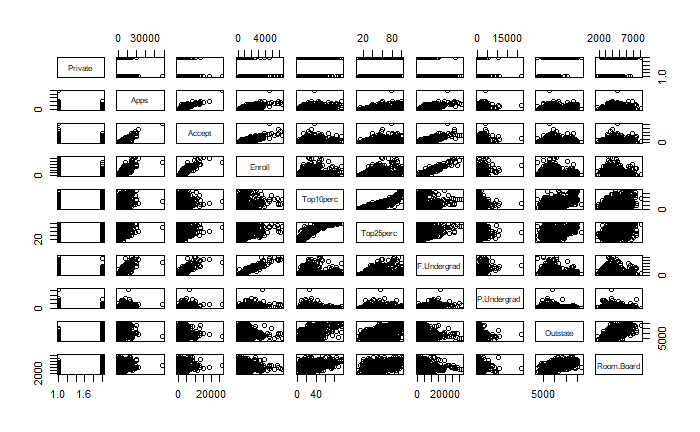

```r
pairs(college[,1:10])
```

### 2.2-c-iii

Which alumni donate more to their colleges — those who go to public schools or those who go to private schools?

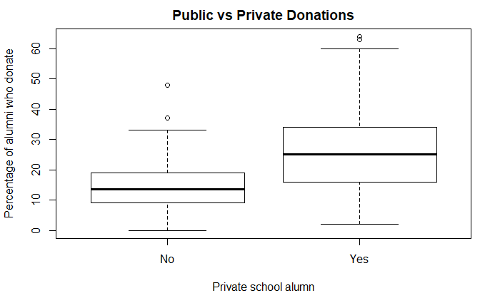

```r
boxplot(perc.alumni~Private, data=college, main = 'Public vs Private Donations', xlab = 'Private school alumn', ylab = 'Percentage of alumni who donate')
```

Which colleges -public or private — employ more Ph.D’s?

### 2.2-c-iv

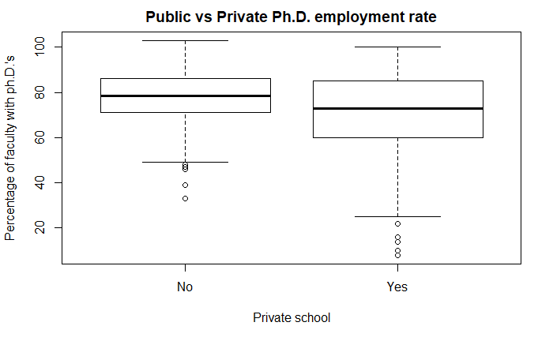

```r
boxplot(PhD~Private, data=college, main = 'Public vs Private Ph.D. employment rate', xlab = 'Private school', ylab = "Percentage of faculty with ph.D.'s")
```

### 2.2-c-v

```r
Elite <- rep("No", nrow(college))
Elite[college$Top10perc > 50] <- "Yes"
Elite <- as.factor(Elite)
college <- data.frame(college, Elite)
summary(Elite)
```

```
 No Yes
699  78
```

### 2.2-c-vi

```r
par(mfrow=c(2,2))
hist(college$Apps, main = 'Number of Applicants Frequency', xlab = 'Number of Applications')
hist(college$Top25perc, main = 'Top 25% Frequency', xlab = 'Percentage of Top 25%')
```

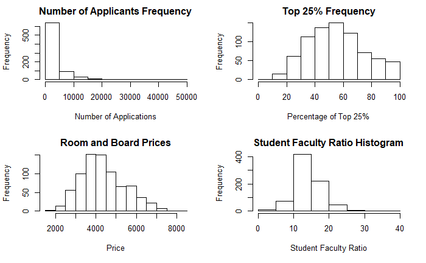

```r
hist(college$Room.Board, main = 'Room and Board Prices', xlab = 'Price')
hist(college$S.F.Ratio, main = 'Student Faculty Ratio Histogram', xlab = 'Student Faculty Ratio')
```

### 2.2-c-extra

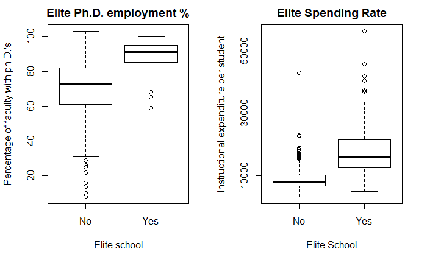

```r
par(mfrow=c(1,2))
boxplot(PhD~Elite, data=college, main = 'Elite Ph.D. employment %', xlab = 'Elite school', ylab = "Percentage of faculty with ph.D.'s")
boxplot(Expend~Elite, data=college, main = 'Elite Spending Rate', xlab = 'Elite School', ylab = 'Instructional expenditure per student')
```

Based on these two graphs we can determine what makes an elite college so prestegious. For one, they, on average, employ more faculty with Ph.D.’s. On top of that, they often spend more (> 10000) than non elite school. They have the talent and the money to be successful universities.

## Problem 2.2: Linear Regression

### 2.2-a

I believe that Field goals should be the attribute most correlated to Points Scored, simply because Field Goals are the most common way to score points in basketball.

```r
nba <- read.csv("nba.csv")
summary(nba)
```

```
                      SEASON            DATE         PLAYER.FULLNAME POSITION         OWNTEAM         OPPTEAM    VENUE        MIN
 2017-2018 Regular Season:269   10/17/2017: 40   Al Horford  :  2    C :38    Boston      : 20   Houston  : 22   H:137   Min.   : 0.20
                                10/18/2017:229   Aron Baynes :  2    PF:60    Houston     : 17   Boston   : 20   R:132   1st Qu.:15.90
                                                 Clint Capela:  2    PG:57    San Antonio : 13   Minnesota: 13           Median :24.10
                                                 Eric Gordon :  2    SF:54    Atlanta     : 12   Dallas   : 12           Mean   :23.21
                                                 James Harden:  2    SG:60    Denver      : 12   Portland : 12           3rd Qu.:31.60
                                                 Jaylen Brown:  2             Golden State: 12   Utah     : 12           Max.   :43.40
                                                 (Other)     :257             (Other)     :183   (Other)  :178
       FG              FGA              X3P              X3PA             FT              FTA               OR              DR              TOT
 Min.   : 0.000   Min.   : 0.000   Min.   :0.0000   Min.   : 0.00   Min.   : 0.000   Min.   : 0.000   Min.   :0.000   Min.   : 0.000   Min.   : 0.000
 1st Qu.: 2.000   1st Qu.: 4.000   1st Qu.:0.0000   1st Qu.: 1.00   1st Qu.: 0.000   1st Qu.: 0.000   1st Qu.:0.000   1st Qu.: 1.000   1st Qu.: 2.000
 Median : 3.000   Median : 8.000   Median :1.0000   Median : 2.00   Median : 1.000   Median : 2.000   Median :1.000   Median : 2.000   Median : 4.000
 Mean   : 3.859   Mean   : 8.535   Mean   :0.9628   Mean   : 2.71   Mean   : 1.766   Mean   : 2.219   Mean   :1.015   Mean   : 3.357   Mean   : 4.372
 3rd Qu.: 6.000   3rd Qu.:12.000   3rd Qu.:1.0000   3rd Qu.: 4.00   3rd Qu.: 2.000   3rd Qu.: 4.000   3rd Qu.:2.000   3rd Qu.: 5.000   3rd Qu.: 6.000
 Max.   :13.000   Max.   :28.000   Max.   :7.0000   Max.   :14.00   Max.   :14.000   Max.   :17.000   Max.   :7.000   Max.   :17.000   Max.   :22.000

       A                PF              ST               TO              BL              PTS
 Min.   : 0.000   Min.   :0.000   Min.   :0.0000   Min.   :0.000   Min.   :0.0000   Min.   : 0.00
 1st Qu.: 0.000   1st Qu.:1.000   1st Qu.:0.0000   1st Qu.:0.000   1st Qu.:0.0000   1st Qu.: 4.00
 Median : 1.000   Median :2.000   Median :0.0000   Median :1.000   Median :0.0000   Median : 9.00
 Mean   : 2.149   Mean   :2.059   Mean   :0.7323   Mean   :1.394   Mean   :0.5576   Mean   :10.45
 3rd Qu.: 3.000   3rd Qu.:3.000   3rd Qu.:1.0000   3rd Qu.:2.000   3rd Qu.:1.0000   3rd Qu.:15.00
 Max.   :13.000   Max.   :6.000   Max.   :4.0000   Max.   :8.000   Max.   :7.0000   Max.   :37.00
```

```r
FG_PTS <- lm(PTS~FG, data=nba)
summary(FG_PTS)
```

```
Call:
lm(formula = PTS ~ FG, data = nba)

Residuals:
    Min      1Q  Median      3Q     Max
-5.7986 -1.2524 -0.3616  0.8569  9.4199

Coefficients:
            Estimate Std. Error t value Pr(>|t|)
(Intercept)  0.58848    0.22751   2.587   0.0102 *
FG           2.55462    0.04715  54.186   <2e-16 ***
---
Signif. codes:  0 *** 0.001 ** 0.01 * 0.05 . 0.1   1

Residual standard error: 2.241 on 267 degrees of freedom
Multiple R-squared:  0.9166,    Adjusted R-squared:  0.9163
F-statistic:  2936 on 1 and 267 DF,  p-value: < 2.2e-16
```

The model tells me that for ever Field Goal the points should go up by 2.55 and that PTS should start at 0.59, but since there is only one predictor it accounts for the lack of free throws and three pointers. An average of 3.86 FG’s were made and an average of 10.45 PTS were made, which should be an average of (2.55 * 3.86) + 0.588 = 10.431. The model overestimates the value of a Field Goal but it fits the model very well.

### 2.2-b

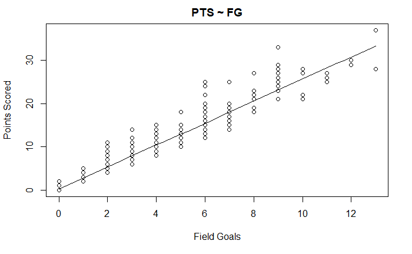

```r
scatter.smooth(x=nba$FG, y=nba$PTS, main = "PTS ~ FG", xlab = 'Field Goals', ylab = 'Points Scored')
```

### 2.2-seed

```r
set.seed(1122)
index <- sample(1:nrow(nba), 250)
train <- nba[index, ]
test <- nba[-index, ]
summary(train)
```

```
                      SEASON            DATE         PLAYER.FULLNAME POSITION         OWNTEAM        OPPTEAM    VENUE        MIN              FG
 2017-2018 Regular Season:250   10/17/2017: 37   Al Horford  :  2    C :35    Boston      : 15   Houston : 22   H:128   Min.   : 0.20   Min.   : 0.000
                                10/18/2017:213   Aron Baynes :  2    PF:55    Houston     : 14   Boston  : 20   R:122   1st Qu.:16.12   1st Qu.: 2.000
                                                 Clint Capela:  2    PG:50    Golden State: 12   Dallas  : 11           Median :24.70   Median : 3.000
                                                 Eric Gordon :  2    SF:51    Atlanta     : 11   Portland: 11           Mean   :23.47   Mean   : 3.944
                                                 James Harden:  2    SG:59    Denver      : 11   Utah    : 11           3rd Qu.:31.60   3rd Qu.: 6.000
                                                 Jaylen Brown:  2             Phoenix     : 11   Atlanta : 10           Max.   :43.40   Max.   :13.000
                                                 (Other)     :238             (Other)     :176   (Other) :165
      FGA              X3P             X3PA              FT              FTA               OR              DR              TOT               A
 Min.   : 0.000   Min.   :0.000   Min.   : 0.000   Min.   : 0.000   Min.   : 0.000   Min.   :0.000   Min.   : 0.000   Min.   : 0.000   Min.   : 0.000
 1st Qu.: 4.000   1st Qu.:0.000   1st Qu.: 1.000   1st Qu.: 0.000   1st Qu.: 0.000   1st Qu.:0.000   1st Qu.: 1.000   1st Qu.: 2.000   1st Qu.: 0.000
 Median : 8.000   Median :0.000   Median : 2.000   Median : 1.000   Median : 2.000   Median :1.000   Median : 2.000   Median : 4.000   Median : 1.000
 Mean   : 8.676   Mean   :0.972   Mean   : 2.736   Mean   : 1.812   Mean   : 2.252   Mean   :1.024   Mean   : 3.368   Mean   : 4.392   Mean   : 2.156
 3rd Qu.:12.000   3rd Qu.:1.000   3rd Qu.: 4.000   3rd Qu.: 2.750   3rd Qu.: 4.000   3rd Qu.:2.000   3rd Qu.: 5.000   3rd Qu.: 6.000   3rd Qu.: 3.000
 Max.   :28.000   Max.   :7.000   Max.   :14.000   Max.   :14.000   Max.   :17.000   Max.   :7.000   Max.   :17.000   Max.   :22.000   Max.   :13.000

       PF             ST              TO              BL             PTS
 Min.   :0.00   Min.   :0.000   Min.   :0.000   Min.   :0.000   Min.   : 0.00
 1st Qu.:1.00   1st Qu.:0.000   1st Qu.:0.000   1st Qu.:0.000   1st Qu.: 4.25
 Median :2.00   Median :0.000   Median :1.000   Median :0.000   Median :10.00
 Mean   :2.12   Mean   :0.704   Mean   :1.412   Mean   :0.576   Mean   :10.67
 3rd Qu.:3.00   3rd Qu.:1.000   3rd Qu.:2.000   3rd Qu.:1.000   3rd Qu.:15.00
 Max.   :6.00   Max.   :4.000   Max.   :8.000   Max.   :7.000   Max.   :37.00
```

### 2.2-c

```r
regressors <- data.frame(train$FG, train$FGA, train$X3P, train$X3PA, train$FT, train$FTA, train$TOT, train$TO, train$A, train$ST, train$BL, train$PTS)
psych::corr.test(regressors)
```

```
Call:psych::corr.test(x = regressors)
Correlation matrix
           train.FG train.FGA train.X3P train.X3PA train.FT train.FTA train.TOT train.TO train.A train.ST train.BL train.PTS
train.FG       1.00      0.87      0.47       0.45     0.43      0.44      0.50     0.40    0.38     0.28     0.24      0.96
train.FGA      0.87      1.00      0.43       0.60     0.49      0.48      0.45     0.44    0.47     0.32     0.22      0.87
train.X3P      0.47      0.43      1.00       0.80     0.09      0.07      0.02     0.13    0.24     0.18    -0.04      0.54
train.X3PA     0.45      0.60      0.80       1.00     0.21      0.19      0.05     0.22    0.33     0.28    -0.01      0.53
train.FT       0.43      0.49      0.09       0.21     1.00      0.97      0.40     0.37    0.20     0.11     0.16      0.64
train.FTA      0.44      0.48      0.07       0.19     0.97      1.00      0.40     0.37    0.19     0.12     0.16      0.63
train.TOT      0.50      0.45      0.02       0.05     0.40      0.40      1.00     0.32    0.16     0.12     0.41      0.50
train.TO       0.40      0.44      0.13       0.22     0.37      0.37      0.32     1.00    0.32     0.05     0.20      0.43
train.A        0.38      0.47      0.24       0.33     0.20      0.19      0.16     0.32    1.00     0.25     0.03      0.38
train.ST       0.28      0.32      0.18       0.28     0.11      0.12      0.12     0.05    0.25     1.00     0.01      0.27
train.BL       0.24      0.22     -0.04      -0.01     0.16      0.16      0.41     0.20    0.03     0.01     1.00      0.22
train.PTS      0.96      0.87      0.54       0.53     0.64      0.63      0.50     0.43    0.38     0.27     0.22      1.00
Sample Size
[1] 250
Probability values (Entries above the diagonal are adjusted for multiple tests.)
           train.FG train.FGA train.X3P train.X3PA train.FT train.FTA train.TOT train.TO train.A train.ST train.BL train.PTS
train.FG          0         0      0.00       0.00     0.00      0.00      0.00     0.00    0.00     0.00     0.00      0.00
train.FGA         0         0      0.00       0.00     0.00      0.00      0.00     0.00    0.00     0.00     0.01      0.00
train.X3P         0         0      0.00       0.00     1.00      1.00      1.00     0.61    0.00     0.09     1.00      0.00
train.X3PA        0         0      0.00       0.00     0.01      0.04      1.00     0.01    0.00     0.00     1.00      0.00
train.FT          0         0      0.18       0.00     0.00      0.00      0.00     0.00    0.02     0.95     0.19      0.00
train.FTA         0         0      0.26       0.00     0.00      0.00      0.00     0.00    0.04     0.61     0.18      0.00
train.TOT         0         0      0.76       0.42     0.00      0.00      0.00     0.00    0.18     0.61     0.00      0.00
train.TO          0         0      0.05       0.00     0.00      0.00      0.00     0.00    0.00     1.00     0.03      0.00
train.A           0         0      0.00       0.00     0.00      0.00      0.01     0.00    0.00     0.00     1.00      0.00
train.ST          0         0      0.01       0.00     0.09      0.05      0.05     0.44    0.00     0.00     1.00      0.00
train.BL          0         0      0.58       0.84     0.01      0.01      0.00     0.00    0.67     0.91     0.00      0.01
train.PTS         0         0      0.00       0.00     0.00      0.00      0.00     0.00    0.00     0.00     0.00      0.00

 To see confidence intervals of the correlations, print with the short=FALSE option
```

After looking at the data I felt that Field Goals, Free Throws, and Three Pointers were the most approriate regressors. Field Goal Attempts would have been a redundant addition depsite the high correlation -> more attempts = more field goals. *I changed the model to be a little more interesting because I had a perfect fit model - I wanted to see how factors other than Field Goals could affect the score.

### 2.2-d

```r
multiModel <- lm(PTS ~ TOT + X3P + FT, data=train)
summary(multiModel)
```

```
Call:
lm(formula = PTS ~ TOT + X3P + FT, data = train)

Residuals:
    Min      1Q  Median      3Q     Max
-9.2521 -2.8166 -0.8268  1.9572 19.9902

Coefficients:
            Estimate Std. Error t value Pr(>|t|)
(Intercept)  2.22736    0.45094   4.939 1.45e-06 ***
TOT          0.60766    0.07545   8.054 3.45e-14 ***
X3P          2.97601    0.20280  14.675  < 2e-16 ***
FT           1.59114    0.12158  13.087  < 2e-16 ***
---
Signif. codes:  0 *** 0.001 ** 0.01 * 0.05 . 0.1   1

Residual standard error: 4.174 on 246 degrees of freedom
Multiple R-squared:  0.7227,    Adjusted R-squared:  0.7193
F-statistic: 213.7 on 3 and 246 DF,  p-value: < 2.2e-16
```

### 2.2-e

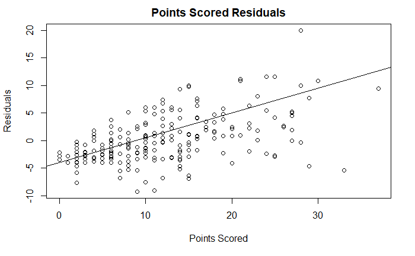

```r
multiModelRes = resid(multiModel)
plot(train$PTS, multiModelRes, ylab = 'Residuals',
     xlab = 'Points Scored', main = 'Points Scored Residuals')
abline(-4,0.45)
```

I drew a line that sort of represents the shape of the residual - It’s a positively sloped line.

### 2.2-f

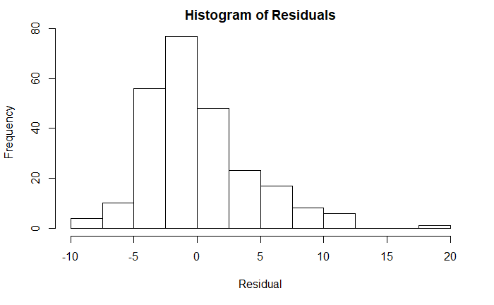

```r
hist(multiModelRes, xlab = 'Residual', main = 'Histogram of Residuals',
     breaks = c(-10, -7.5, -5, -2.5, 0, 2.5, 5, 7.5, 10, 12.5, 15, 17.5, 20 ))
```

This is a right skewed graph, but it mostly follows a gaussian curve.

### 2.2-g

```r
predict <- predict(multiModel, test)
predict <- data.frame(predict, test$PTS)
as.data.frame(table(predict$predict == predict$test.PTS))
```

| Var1 | Freq |
| --- | --- |
| FALSE | 19 |

### 2.2-h

```r
residuals <- predict$test.PTS - predict$predict
RSS <- sum(residuals^2)
TSS <- residuals - (sum(residuals/19))
TSS <- sum(TSS^2)
fSTAT <- ((TSS - RSS) / 0.05) / (RSS / (19 - 0.05 - 1))
RSE <- sqrt(RSS / (19 - 0.05 - 1))
print(paste("RSS:", RSS))
```

```
[1] "RSS: 224.209235874212"
```

```r
print(paste("TSS:", TSS))
```

```
[1] "TSS: 175.767254494554"
```

```r
print(paste("F-Statistic (p = 0.05):", fSTAT))
```

```
[1] "F-Statistic (p = 0.05): -77.5644734147075"
```

```r
print(paste("RSE:", RSE))
```

```
[1] "RSE: 3.53422767090083"
```

There is something wrong with the f-statistic.